# Afastamento e impeachment de Dilma Rousseff e a rotatividade dos cargos comissionados

Daniel Marques

2024-07-17

# O que será analisado?

Será utilizada base de dados de elaboração própria que contém a **rotatividade mensal dos cargos de livre provimento do Executivo**.

A formulação teórica sugere que as mudanças intitucionais no Brasil e os momentos de instabilidade devem ter aumentado o custo da coalização governamental. Portanto…

**A hipótese a ser testada:** o afastamento de Dilma Rousseff (agosto de 2016) aumentou a rotatividade dos cargos comissionados?

# Preparação

## Carregando pacotes

```r
pacman::p_load("tidyverse", "lubridate", "readr", "scales", "infer")
```

## Lendo e processando o arquivo CSV

Aqui, aproveito para configurar o formato da coluna que representa a data e identifica qual o mês a que se refere o dado.

```r
setwd("~/Lista4/tarefa5/tarefa5")
calculo_rotatividade_b <- read_csv("calculo_rotatividade_b.csv") %>%
  mutate(mes = ymd(mes))
```

# Antes e depois do afastamento

É preciso definir uma variável categórica para separar os dados referentes aos períodos posterior e anterior ao afastamento de Dilma. A variável “pos_imp” terá o valor “1” para o período após o afastamento e “0” para antes do afastamento.

```r
calculo_rotatividade_b <- calculo_rotatividade_b %>%
  mutate(ano = year(mes),
         pos_imp = if_else(mes > ymd("2016-08-31"), 1, 0))
```

# Realizando o teste T

```r
t.test(percent_rotat ~ pos_imp, data = calculo_rotatividade_b)
```

```
##
##  Welch Two Sample t-test
##
## data:  percent_rotat by pos_imp
## t = -4.1022, df = 132.42, p-value = 7.106e-05
## alternative hypothesis: true difference in means between group 0 and group 1 is not equal to 0
## 95 percent confidence interval:
##  -1.5649057 -0.5467039
## sample estimates:
## mean in group 0 mean in group 1
##        3.117286        4.173090
```

**Achados:**

Média de rotatividade no período pré-impeachment: ~ 3,12% Média pós-impeachment: ~ 4,17%

O valor t inferior a 0 (-4.1022) indica que a *média mensal de rotatividade dos servidores comissionados é menor antes do afastamento de Dilma*.

O p-valor de número muito pequeno (7.106e−05 = 0.00007106) indica que *a diferença entre os dois momentos observados é estatisticamente significativa.*

# Construindo gráficos

## Armazenando dados estatísticos

Aqui, solicito ao R o cálculo dos dados: média de cada período (mean), e o intervalo de confiança (ci).

```r
summary_stats <- calculo_rotatividade_b %>%
  group_by(pos_imp) %>%
  summarize(
    mean_percent_rotat = mean(percent_rotat, na.rm = TRUE),
    ci_lower = mean_percent_rotat - qt(0.975, df=n()-1) * sd(percent_rotat, na.rm = TRUE)/sqrt(n()),
    ci_upper = mean_percent_rotat + qt(0.975, df=n()-1) * sd(percent_rotat, na.rm = TRUE)/sqrt(n())
  )
```

# Gráfico de densidade

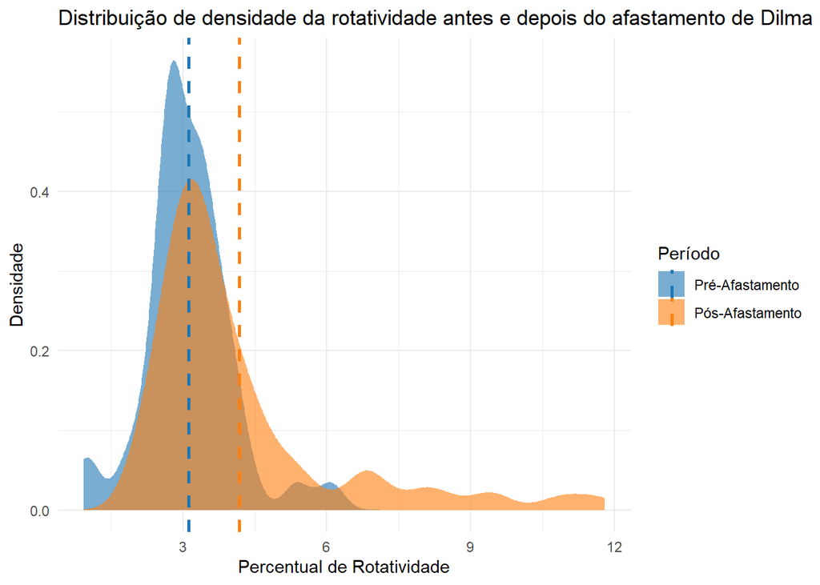

```r
# Calculando as médias para cada grupo
mean_values <- calculo_rotatividade_b %>%
  group_by(pos_imp) %>%
  summarize(mean_percent_rotat = mean(percent_rotat, na.rm = TRUE))


ggplot(calculo_rotatividade_b, aes(x = percent_rotat, fill = factor(pos_imp, labels = c("Pré-Afastamento", "Pós-Afastamento")))) +
  geom_density(alpha = 0.6, color = NA) +
  geom_vline(data = mean_values, aes(xintercept = mean_percent_rotat, color = factor(pos_imp, labels = c("Pré-Afastamento", "Pós-Afastamento"))), linetype = "dashed", size = 1) +
  scale_fill_manual(values = c("#1F77B4", "#FF7F0E")) + # cores mais escuras
  scale_color_manual(values = c("#1F77B4", "#FF7F0E")) + # corresponder as cores das linhas às áreas de densidade
  labs(
    title = "Distribuição de densidade da rotatividade antes e depois do afastamento de Dilma",
    x = "Percentual de Rotatividade",
    y = "Densidade",
    fill = "Período",
    color = "Período"
  ) +
  theme_minimal()
```

# Médias e intervalo de confiança

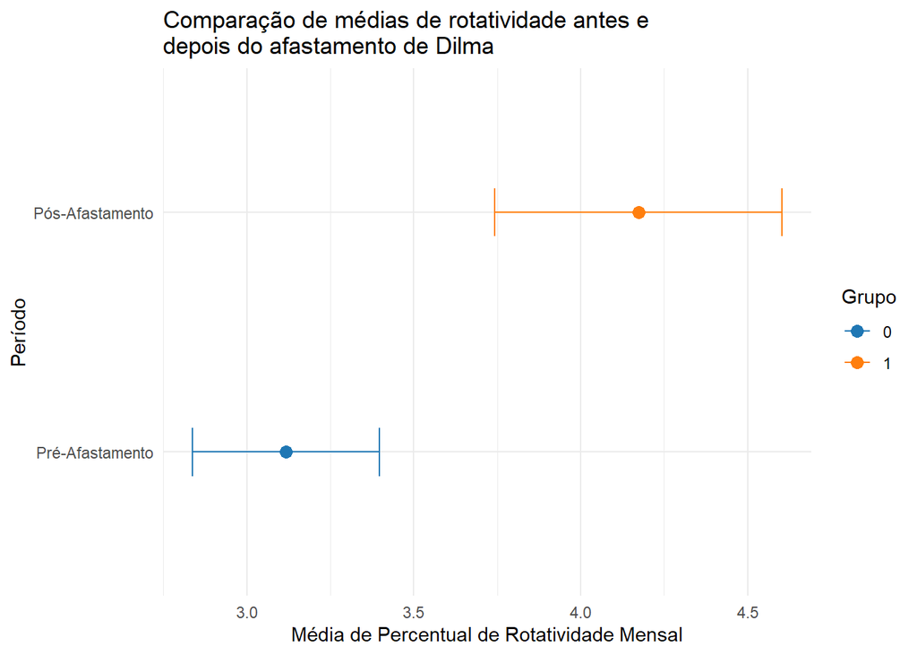

```r
ggplot(summary_stats, aes(y = factor(pos_imp, labels = c("Pré-Afastamento", "Pós-Afastamento")), x = mean_percent_rotat, color = factor(pos_imp))) +
  geom_point(size = 3) +
  geom_errorbarh(aes(xmin = ci_lower, xmax = ci_upper), height = 0.2) +
  scale_color_manual(values = c("#1F77B4", "#FF7F0E")) +
  labs(
    title = "Comparação de médias de rotatividade antes e\ndepois do afastamento de Dilma",
    x = "Média de Percentual de Rotatividade Mensal",
    y = "Período",
    color = "Grupo"
  ) +
  theme_minimal()
```

## Gráfico linear

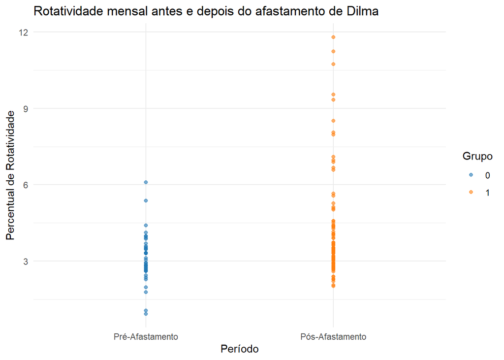

```r
ggplot(calculo_rotatividade_b, aes(y = percent_rotat, x = factor(pos_imp, labels = c("Pré-Afastamento", "Pós-Afastamento")), color = factor(pos_imp))) +
  geom_point(alpha = 0.6) +
  geom_smooth(method = "lm", se = FALSE, linetype = "dashed", color = "black") +
  scale_color_manual(values = c("#1F77B4", "#FF7F0E")) + # cores mais escuras
  labs(
    title = "Rotatividade mensal antes e depois do afastamento de Dilma",
    y = "Percentual de Rotatividade",
    x = "Período",
    color = "Grupo"
  ) +
  theme_minimal()
```